# New York Evictions

## Originality declaration

I, [Chi Chin Christy Choi], confirm that the work presented in this assessment is my own. Where information has been derived from other sources, I confirm that this has been indicated in the work. ChatGPT and Gemini have been used to fix grammar, coding issues and tidy text writings.

# New York Evictions

New York City wish to conduct a study that aims to prevent people being evicted through understand possible related factors.You have been enlisted as a consultant and tasked to conduct an analysis of their data from 2020.

You should use appropriate data processing and analysis methods to produce an overview report which summarises the patterns revealed in the data in this year. It is expected that at least some of the methods you use will relate to the spatial dimensions of the data.

Your report should include a brief introduction including relevant contextual information at the beginning and a critical review of your findings at the end. You must include at least one map.

### Data Sources

- List of evictions - https://data.cityofnewyork.us/City-Government/Evictions/6z8x-wfk4
- New York City community districts - https://www.nyc.gov/content/planning/pages/resources/datasets/community-districts

## 1. Initial Project Scope

### Background

Evictions are closely linked with economic hardships and social instability, often contibuting to homelessness and psychological distress, disproportionately impacting the more vulnerable population of the city. In New York City, around two-thirds of households rent their homes, with a large proportion considered themselves as “housing cost burdened”, spending 30-50% of income on rents (nyc.gov, 2024). With a context of high living costs and spatial inequality, this can further exacerbates eviction rates within the city.

Policies have been introduced in mitigation to strengthen tenants protection and avoid evictions. Most relevant to this analysis is the Housing Stability and Tenant Protection Act 2019 (HSTPA), covering New York on the state level, aimed to strengthen eviction protection through limiting tenancy terminations, mandating longer notices periods, and a series of tenant rights protection measures. The analysis on evictions in 2020 therefore will be reflecting the housing market under this stricter regulatory and legal frameworks.

Furthermore, the year 2020 was largely affected by the COVID-19 pandemic, which intensified these pressures. This period precipitated a severe economic crisis in the United States, highlighting higher rates of unemployment and income drops. In response, the state introduced the Eviction Moratoriums measures, aimed to protect tenants from evictions due to the unforeseen circumstances such as failing to pay their rent. All things considered, these factors have motivated the analysis aims to give a better understanding of the spatial distribution of eviction patterns across community district boundaries of New York City, identifying areas of eviction concentration, supporting policy makers for informed decision making and strengthen renter tenancy protection measures.

### Research Question

The following analysis will aim to answer the following research question: *Which areas exhibits spatial ‘hotspots’ clustering activity of residential evictions within the community district boundaries in New York City in 2020?*

### Data Evaluation

- Evictions
  - Nature: point data with location, date, types of evictions
  - Strength: provided precise geocoded location (Latitude/Longitude) allowing for spatial analysis, and differentiates between “Residential” and “Commercial” tenancy types
  - Weaknesses: missing values in Latitude and Longitude columns, data only covered executed evictions where informal evictions were not available, population and household counts were not available which limits the calculation for eviction rates.
- Community Districts
  - Nature: polygon data with administrative boundaries of 59 districts and 12 joint interest areas (JIAs)
  - Strength: official community boundaries used for planning and policies allowing analysis to be interpretable for policy recommendation purposes, standard CRS and metadata provided
  - Weaknesses: community districts varies in size aggregating data points on large polygons may risk modifiable areal unit problem (MAUP), JIAs refers to non-residential areas which may distort the analysis if not removed

### Data Wrangling Explanation

- Load in CSV and Shapefile
- Convert CSV into sf object, latitude and longitude columns present in CSV
- Transform CRS, make sure common CRS for both
- Filter dates for year 2020 only
- Perform a spatial join for evictions count per community district

### Plan

- Data Process
  - Data loading, cleaning, CRS projection, plot points and polygons for data inspection
- Descriptive overview of eviction patterns
  - Bar chart - identify evictions counts per borough
- Exploratory Point Pattern Analysis
  - Kernel Density Estimation to visually identify a broad initial identification of high and low eviction intensity and potential hotspot
- Spatial Autocorrelation
  - Join eviction points with district polygons for a choropleth map of eviction density across New York
  - Global Moran’s I to test whether similar values (high or low) tend to cluster in space, testing global (overall) spatial autocorrelation
  - Local Moran’s I to identifies where local clustering of eviction intensity is strongest in New York supported with a z-score density map to identify clusters and outliers using queen contiguity weights
  - Local Getis-Ord Gi* Hotspot Map would be the final map to answer the research question

## 2. Data Loading and Processing

```r
# remove objects from workspace and clear memory
rm(list = ls())
gc()
```

```
##           used (Mb) gc trigger (Mb) max used (Mb)
## Ncells  612409 32.8    1398702 74.7   702074 37.5
## Vcells 1146974  8.8    8388608 64.0  1928237 14.8
```

### Load Packages

```r
library(sf)
library(here)
library(tidyverse)
library(janitor)
library(tmap)
library(tmaptools)
library(sp)
library(spatstat)
library(spdep)
library(RColorBrewer)
```

### Data Loading

The community district polygons are provided in the CRS projection of NAD83/ New York Long Island (ftUS) measured in feets. NAD83 in meters is EPSG:32118. Therefore the conversion of eviction points from WSG84 to NAD83 (in meters) is needed to ensure a consistent CRS for valid spatial joins. For the CSV data, removing any missing rows of Longitude and Latitude and converting the filtered tibble into an sf object would be the first step before CRS projection.

```r
#read in community districts boundaries data
districts <- st_read(here::here("New York Evictions Data", "nycd.shp"))%>%
  #transform CRS to EPSG:32118 (meters version of NAD83)
  st_transform(32118)
#check if CRS is transformed to EPSG:32118
st_crs(districts)
```

```
## Coordinate Reference System:
##   User input: EPSG:32118
##   wkt:
## PROJCRS["NAD83 / New York Long Island",
##     BASEGEOGCRS["NAD83",
##         DATUM["North American Datum 1983",
##             ELLIPSOID["GRS 1980",6378137,298.257222101,
##                 LENGTHUNIT["metre",1]]],
##         PRIMEM["Greenwich",0,
##             ANGLEUNIT["degree",0.0174532925199433]],
##         ID["EPSG",4269]],
##     CONVERSION["SPCS83 New York Long Island zone (meter)",
##         METHOD["Lambert Conic Conformal (2SP)",
##             ID["EPSG",9802]],
##         PARAMETER["Latitude of false origin",40.1666666666667,
##             ANGLEUNIT["degree",0.0174532925199433],
##             ID["EPSG",8821]],
##         PARAMETER["Longitude of false origin",-74,
##             ANGLEUNIT["degree",0.0174532925199433],
##             ID["EPSG",8822]],
##         PARAMETER["Latitude of 1st standard parallel",41.0333333333333,
##             ANGLEUNIT["degree",0.0174532925199433],
##             ID["EPSG",8823]],
##         PARAMETER["Latitude of 2nd standard parallel",40.6666666666667,
##             ANGLEUNIT["degree",0.0174532925199433],
##             ID["EPSG",8824]],
##         PARAMETER["Easting at false origin",300000,
##             LENGTHUNIT["metre",1],
##             ID["EPSG",8826]],
##         PARAMETER["Northing at false origin",0,
##             LENGTHUNIT["metre",1],
##             ID["EPSG",8827]]],
##     CS[Cartesian,2],
##         AXIS["easting (X)",east,
##             ORDER[1],
##             LENGTHUNIT["metre",1]],
##         AXIS["northing (Y)",north,
##             ORDER[2],
##             LENGTHUNIT["metre",1]],
##     USAGE[
##         SCOPE["Engineering survey, topographic mapping."],
##         AREA["United States (USA) - New York - counties of Bronx; Kings; Nassau; New York; Queens; Richmond; Suffolk."],
##         BBOX[40.47,-74.26,41.3,-71.8]],
##     ID["EPSG",32118]]
```

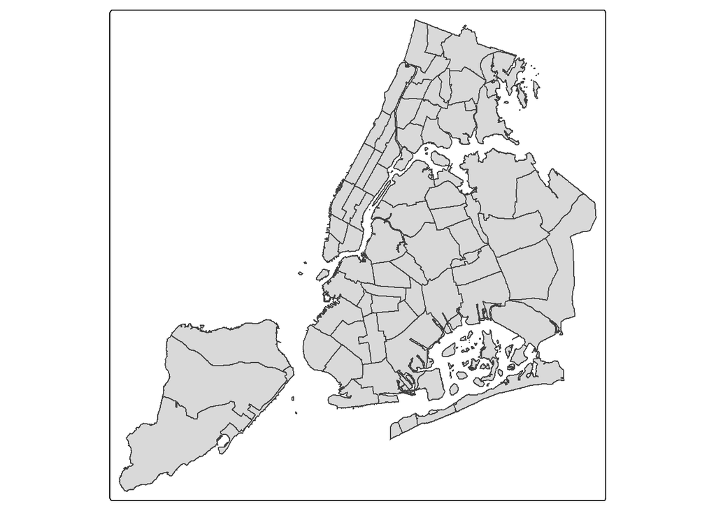

```r
#quick plot map for initial inspection of the boundaries
qtm(districts)
```

```r
#read in csv raw data and project to NAD83
evictions <- read_csv(here::here("New York Evictions Data", "Evictions_20251103.csv")) %>%
  #remove NaN values where location is unknown
  dplyr::filter(!is.na(Longitude),
                !is.na(Latitude)) %>%
  #convert into sf object,
  st_as_sf(coords = c("Longitude", "Latitude"),
           crs = 4326)%>%
  #transform CRS to match districts
  st_transform(32118)
#check if evictions is projected to NAD83
st_crs(evictions)
```

```
## Coordinate Reference System:
##   User input: EPSG:32118
##   wkt:
## PROJCRS["NAD83 / New York Long Island",
##     BASEGEOGCRS["NAD83",
##         DATUM["North American Datum 1983",
##             ELLIPSOID["GRS 1980",6378137,298.257222101,
##                 LENGTHUNIT["metre",1]]],
##         PRIMEM["Greenwich",0,
##             ANGLEUNIT["degree",0.0174532925199433]],
##         ID["EPSG",4269]],
##     CONVERSION["SPCS83 New York Long Island zone (meter)",
##         METHOD["Lambert Conic Conformal (2SP)",
##             ID["EPSG",9802]],
##         PARAMETER["Latitude of false origin",40.1666666666667,
##             ANGLEUNIT["degree",0.0174532925199433],
##             ID["EPSG",8821]],
##         PARAMETER["Longitude of false origin",-74,
##             ANGLEUNIT["degree",0.0174532925199433],
##             ID["EPSG",8822]],
##         PARAMETER["Latitude of 1st standard parallel",41.0333333333333,
##             ANGLEUNIT["degree",0.0174532925199433],
##             ID["EPSG",8823]],
##         PARAMETER["Latitude of 2nd standard parallel",40.6666666666667,
##             ANGLEUNIT["degree",0.0174532925199433],
##             ID["EPSG",8824]],
##         PARAMETER["Easting at false origin",300000,
##             LENGTHUNIT["metre",1],
##             ID["EPSG",8826]],
##         PARAMETER["Northing at false origin",0,
##             LENGTHUNIT["metre",1],
##             ID["EPSG",8827]]],
##     CS[Cartesian,2],
##         AXIS["easting (X)",east,
##             ORDER[1],
##             LENGTHUNIT["metre",1]],
##         AXIS["northing (Y)",north,
##             ORDER[2],
##             LENGTHUNIT["metre",1]],
##     USAGE[
##         SCOPE["Engineering survey, topographic mapping."],
##         AREA["United States (USA) - New York - counties of Bronx; Kings; Nassau; New York; Queens; Richmond; Suffolk."],
##         BBOX[40.47,-74.26,41.3,-71.8]],
##     ID["EPSG",32118]]
```

```r
#check if both CRS is the same
st_crs(evictions) == st_crs(districts)
```

```
## [1] TRUE
```

### Data Processing

#### Data Cleaning

To narrow down the focus for 2020 data and residential eviction analysis only, this section included data cleaning, cleaning names for consistent variable names, selecting columns needed for the analysis, filtering data for dates between 2020/01/01 to 2020/12/31 only (Stack Overflow, n.d.) and filtering eviction legal possession to Residential only. A data sanity check was performed after data cleaning for verification of total number of rows, summary of the date column (minimum and maximum date value), and listed the distinct categories for the residential_commercial column.

```r
#clean evictions
evictions_clean <- evictions %>%
  clean_names() %>%
  #selected columns needed for analysis
  select(executed_date, residential_commercial, borough,eviction_legal_possession, geometry) %>%
  # filtering date for dates within 2020 only (Stack Overflow, n.d.)
  mutate(executed_date = as.Date(executed_date, format = "%m/%d/%Y")) %>%
  filter(executed_date >= "2020-01-01",
         executed_date <= "2020-12-31",
         #filter for residential evictions only
         residential_commercial == "Residential")
```

There are 59 Community Districts and 12 Joint Interest Areas (JIA) in New York, as the analysis is focused on community districts only, removing of the 12 JIAs is essential. The 12 JIAs were identified and selected from the information provided by data source - New York City community districts. The JIA removal was done by calculating district numbers by taking the modulus of the borough code, where JIA numbers were identified and excluded from the dataset. This section of data cleaning for the district polygon also included cleaning names for consistent variable names, and columns needed for the analysis.

```r
#clean districts and remove JIAs
#AI have been used, asked how to remove the 12 JIAs
#(code derived from ChatGPT: mutate(cd_num = boro_cd %% 100,is_jia = cd_num %in% jia_numbers) %>% filter(!is_jia))

jia_numbers <- c(26, 27, 28, 55, 56, 64, 80, 81, 82, 83, 84, 95)

districts_clean <- districts %>%
  clean_names() %>%
  mutate(
    cd_num = boro_cd %% 100,
    is_jia = cd_num %in% jia_numbers) %>%
  filter(!is_jia) %>%
  select(boro_cd, shape_area, geometry)
```

Plot a map to check if the cleaned eviction data points are aligned correctly within the cleaned community district boundaries data, making sure no points lies outside the boundaries.

```r
#plot both layers for data inspection before spatial joins
tmap_mode("plot")
```

```
## ℹ tmap modes "plot" - "view"
## ℹ toggle with `tmap::ttm()`
```

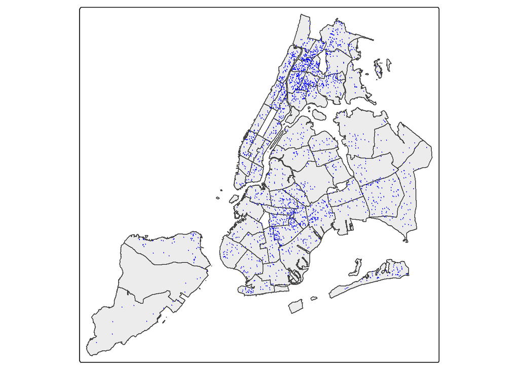

```r
tm_shape(districts_clean) +
  tm_polygons(fill_alpha = 0.5) +
tm_shape(evictions_clean) +
  tm_dots(fill = "blue", size = 0.05)
```

Visual observation have showed that the eviction data point are all well positioned within the New York Community District Boundaries, confirming that the CRS of both data sets are matched and there were no obvious projection problems. Allow to proceed to next section.

## 3. Analysis

#### Analysis Overview

This section will apply descriptive and spatial methods to explore how residential evictions in New York were distributed in 2020. It will start off with a simple summary on the borough level to provide an overview of where evictions occur, followed by point pattern analysis and spatial autocorrelation methods to identify areas which eviction activities are most spatially concentrated.

#### New York Residential Evictions by Borough in 2020

The following provides a bar chart of total number of residential evictions by borough for an inital descriptive overview of eviction patterns. Observing data from a borough level allows easy identification of eviction concentrations within the city, contextualise the following community district level analysis.

```r
#evictions by borough
evictions_borough <- evictions_clean %>%
  st_drop_geometry()%>%
  group_by(borough)%>%
  summarise(evictions_by_borough = n())

evictions_borough
```

```
## # A tibble: 5 × 2
##   borough       evictions_by_borough
##   <chr>                        <int>
## 1 BRONX                          986
## 2 BROOKLYN                       850
## 3 MANHATTAN                      387
## 4 QUEENS                         558
## 5 STATEN ISLAND                   78
```

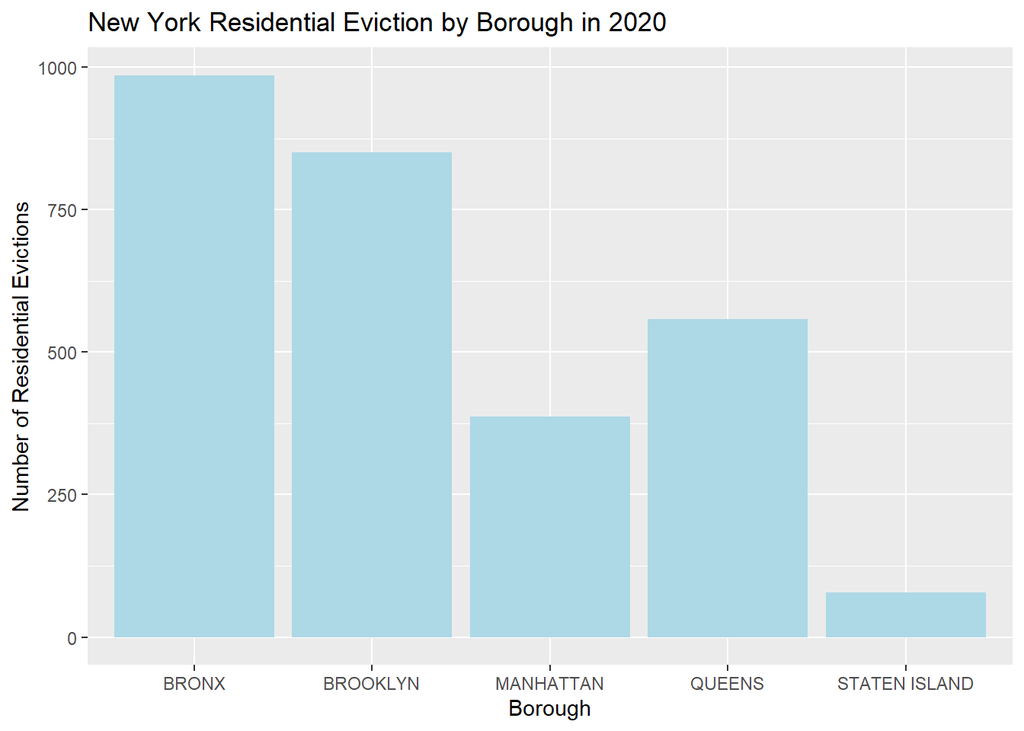

```r
ggplot(evictions_borough,
       aes(x = borough, y = evictions_by_borough)) +
  geom_col(fill = "lightblue") +
  labs(x = "Borough",
       y = "Number of Residential Evictions",
       title = "New York Residential Eviction by Borough in 2020" )
```

The New York Residential Eviction by Borough in 2020 bar chart showed a summary of distribution of eviction activity across the five boroughs. The Bronx and Brooklyn recorded the highest numbers of residential evictions, followed by Queens and Manhattan, while Staten Island showed least number of cases. Population or household data were not available within the data set, therefore, the figure presents raw counts instead of rates, reflecting only the total recorded evictions in each borough. Despite, it still highlighted that evictions were not evenly distributed across the city, suggesting that certain boroughs were relatively more affected. Further exploration would follow for district level density mapping analysis for identifying spatial clusters of eviction activities.

#### Kernel Density Estimation of New York Evictions in 2020

Before moving on to district level analysis, the Kernel Density Estimation Map will be used to provide a initial overview of potential clusters and identify areas of potential “hotspots”. This will give an early visualisation of the concentration of evictions point data under New York Community Districts window, showing an estimation of density spatial patterns in different areas of the city.

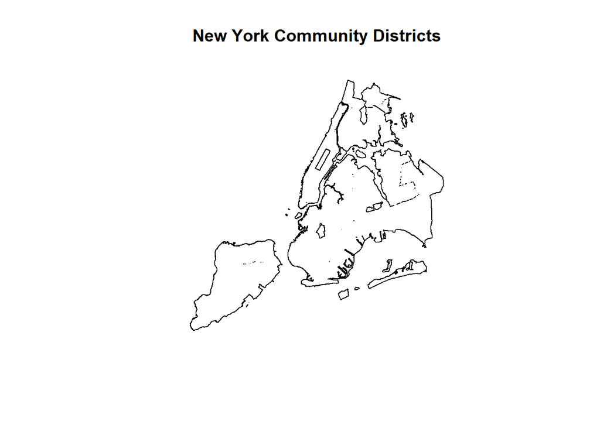

```r
#create a nycd window
nycd_window <- as.owin(districts_clean)

plot(nycd_window, main = "New York Community Districts")
```

```r
#sf -> sp
evictions_sp <- evictions_clean %>%
  as(.,"Spatial")

#create a spatstat ppp object
evictions.ppp <- ppp(x=evictions_sp@coords[,1],
                     y=evictions_sp@coords[,2],
                     window=nycd_window)
```

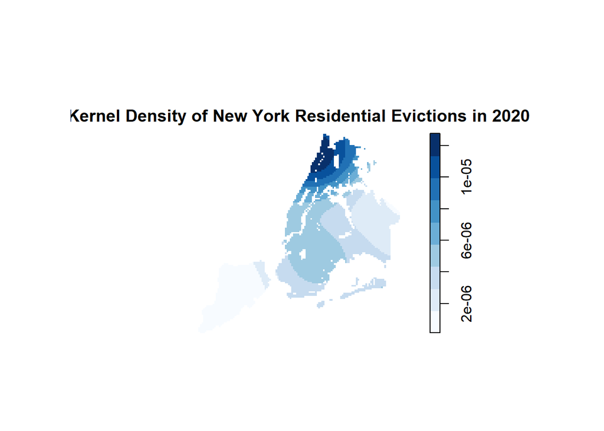

```r
#plot KDE
evictions_kde <- evictions.ppp %>%
  density(., sigma = 5000)

plot(evictions_kde,
     main = "Kernel Density of New York Residential Evictions in 2020",
     col = RColorBrewer::brewer.pal(9, "Blues"))
```

The Kernel Density of New York Residential Evictions in 2020 is a density level map that provides a overall view of eviction density across New York community districts in 2020. Sigma value of 5000 was chosen for clear initial visual identification of hot spots across neighbourhood community districts. The highest density clusters are located in the neighbourhoods of Bronx and Brooklyn, where other community districts showed lower intensity. The density surface highlighted areas of high eviction intensity that spans across multiple district boundaries, for more precise analysis, eviction density per community district will be mapped next.

#### Spatial Autocorrelation - Moran’s I

Here, a choropleth map on calculated density will be used to find out how eviction intensity varies between districts, and test if high eviction districts are located near high eviction districts.

```r
#Calculate Eviction Density per Community District
evictions_density <- districts_clean%>%
  mutate(n = lengths(st_intersects(., evictions_clean)))%>%
  janitor::clean_names()%>%
  #calculate area
  mutate(area=st_area(.))%>%
  #convert area into km2
  mutate(area_km2 = as.numeric(area) / 1000000) %>%
  #density of the points per community district
  mutate(density_km2 = n/area_km2)%>%
  #convert density to km2
  mutate(density_km2 = replace_na(density_km2, 0)) %>%
  #select density and some other variables
  dplyr::select(boro_cd, n, area_km2, density_km2, geometry)
```

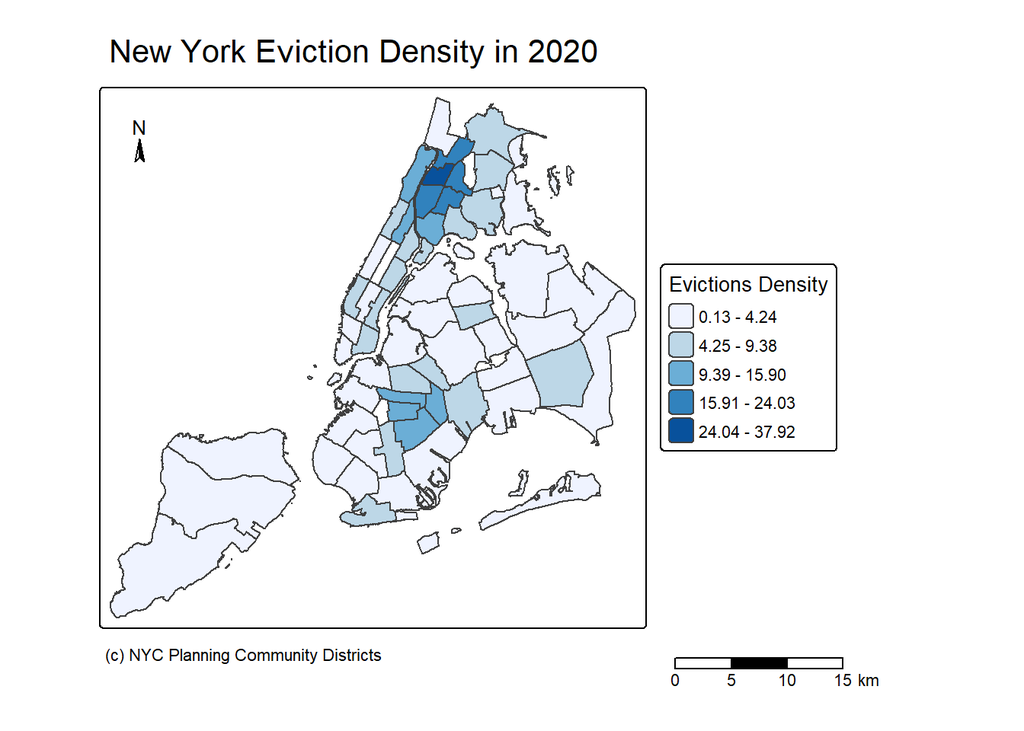

```r
#plot Eviction Density per Community District
tm_shape(evictions_density) +
    tm_polygons(
      fill = "density_km2",
      fill.scale = tm_scale_intervals(
        values = "brewer.blues",
        style="jenks"),
      #set the legend
      fill.legend = tm_legend(title="Evictions Density",
                              title.size=0.85,
                              size=0.8,
                              # plot outside of the main map
                              #explained below
                              position=tm_pos_out("right",
                                                  "center",
                                                  pos.v = "center")))+
  #Compass
  tm_compass(
    type = "arrow", size = 1,
             position = tm_pos_in("left", "top")) +
  #Scale Bar
  tm_scalebar(
    text.size = 0.7,
              position = tm_pos_out("right", "bottom")) +
  #Credits
  tm_credits(
    "(c) NYC Planning Community Districts",
             size = 0.7,
             position = tm_pos_out("center", "bottom")) +
  #Title
  tm_title("New York Eviction Density in 2020")
```

From plotting the density map above, we can see some clustering on community districts level, so let’s check with Moran’s I.

We start with generating a **spatial weight matrix**:

```r
#calculate centroids
districtsW <- evictions_density%>%
  st_centroid()%>%
  st_geometry()
```

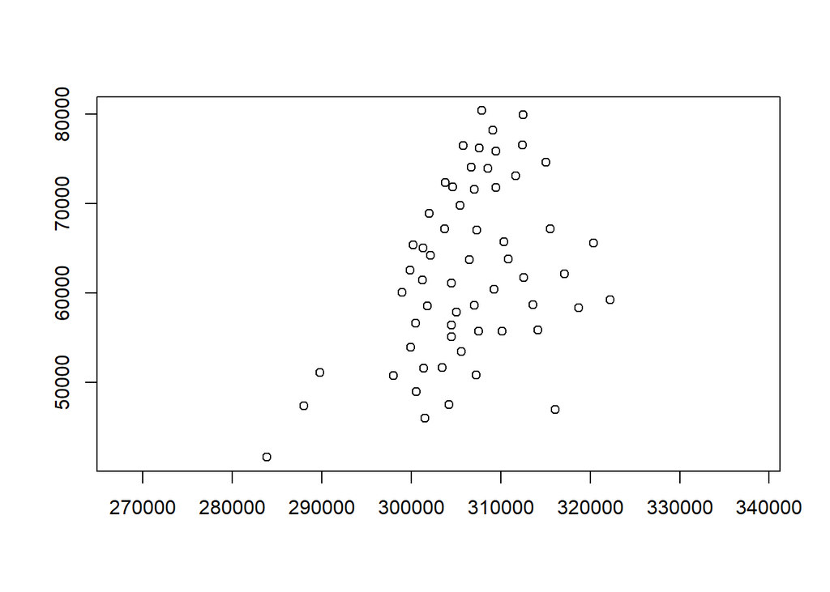

```r
plot(districtsW,axes=TRUE)
```

To include all points that share common features (share common corners or boundary) inclusively, the queen continguity is used to define spatial neighbours. Since observations from previous mappings have shown that New York boundaries included waterfront and island community districts which are separated by water. They may have no contiguous neighbours within the study area, therefore the zero.policy = TRUE is used to permit spatial units with no neighbours under this circumstance to allow them to be retained in the analysis.

```r
#create a neighbours list
districtsW_nb <- evictions_density %>%
  #poly2nb --> find which districts touch each other
  poly2nb(., queen=T)
#create spatial weight matrix from these weights
districtsW_nb_queens <- districtsW_nb %>%
  nb2listw(., style="W",
           #some observations have no neighbours (above code output) --> NYC boundaries have a river in between
           #in this case we allow districts with no neighbours!!
           zero.policy = TRUE)
```

```r
#run Moran's I
morantest <- moran.test(evictions_density$density_km2, districtsW_nb_queens)

morantest
```

```
##
##  Moran I test under randomisation
##
## data:  evictions_density$density_km2
## weights: districtsW_nb_queens
## n reduced by no-neighbour observations
##
## Moran I statistic standard deviate = 6.9742, p-value = 1.538e-12
## alternative hypothesis: greater
## sample estimates:
## Moran I statistic       Expectation          Variance
##       0.631385786      -0.017543860       0.008657715
```

Observing Global Moran’s I queen case statistics is at around 0.63, close to 1 (Moran’s I ranges between -1 and 1) and p-value strictly less than 0.05, indicating statistically significant, strong positive spatial autocorrelation of eviction density data. This suggests that community districts with similar levels of eviction density tend to be located close to each another (high-density districts are statistically are clustered near other high-density districts) rather than a random distribution across New York Community Districts.

This result justifies the necessity of proceeding to the Local Moran’s I and Getis-Ord Gi* analysis to locate these specific “hotspots” and “coldspots” clusters.

#### Spatial Autocorrelation - Local Moran’s I

Moving from an overall city perspective of Global Moran’s I, Local Moran’s I will be used to identify where clustering of residential evictions occurs within New York community districts. Mapping out similarity between neighbours shows high or low eviction intensity, allowing potential hotspots and spatial outliers of districts that do not show strong local clustering to be spotted.

```r
#use the localmoran function to generate I for each disrtict in the New York

#counts
I_evictions_local_counts <- evictions_density %>%
  #extract column - n
  pull(n) %>%
  #convert to vector
  as.vector()%>%
  #calculate local moran's I per district
  localmoran(., districtsW_nb_queens)%>%
  #convert to a tibble
  as_tibble()

#density
I_evictions_local_density <- evictions_density %>%
  #extract column - density_km2
  pull(density_km2) %>%
  as.vector()%>%
  localmoran(., districtsW_nb_queens)%>%
  as_tibble()

#check first 5 output of the local moran object
slice_head(I_evictions_local_density, n=5)
```

```
## # A tibble: 5 × 5
##   Ii         E.Ii         Var.Ii     Z.Ii       `Pr(z != E(Ii))`
##   <localmrn> <localmrn>   <localmrn> <localmrn> <localmrn>
## 1  0.2517082 -0.009610587 0.13300466  0.7165347 0.4736613
## 2 -0.1900314 -0.002210969 0.04186393 -0.9179580 0.3586408
## 3 -0.2070249 -0.002320746 0.04393769 -0.9765807 0.3287768
## 4  0.3694384 -0.018128994 0.19530401  0.8769839 0.3804954
## 5  0.4670830 -0.008412964 0.11657107  1.3926804 0.1637165
```

Next, join statistics back to the spatial polygons:

```r
#mutate local moran's I outputs in evictions_density
evictions_density <- evictions_density %>%
  mutate(evictions_count_I = as.numeric(I_evictions_local_counts$Ii))%>%
  mutate(evictions_count_Iz =as.numeric(I_evictions_local_counts$Z.Ii))%>%
  mutate(density_I =as.numeric(I_evictions_local_density$Ii))%>%
  mutate(density_Iz =as.numeric(I_evictions_local_density$Z.Ii))
```

Mapping Local Moran’s I outputs:

```r
#set breaks
breaks1<-c(-1000,-2.58,-1.96,-1.65,1.65,1.96,2.58,1000)

#create a new diverging colour brewer palette and reverse the order so higher values correspond to red
MoranColours<- rev(brewer.pal(7, "RdBu"))
```

```
## [plot mode] fit legend/component: Some legend items or map compoments do not
## fit well, and are therefore rescaled.
## ℹ Set the tmap option `component.autoscale = FALSE` to disable rescaling.
```

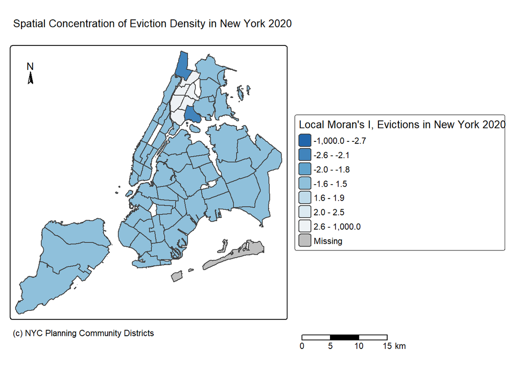

```r
#plot map
tm_shape(evictions_density) +
    tm_polygons(
      fill = "density_Iz",
      fill.scale = tm_scale_intervals(values = MoranColours,
                                      midpoint = "NA",
                                      style = "fixed",
                                      breaks=breaks1),
       fill.legend = tm_legend(title="Local Moran's I, Evictions in New York 2020",
                              title.size=0.85,
                              size=0.8,
                              # plot outside of the main map
                              #explained below
                              position=tm_pos_out("right",
                                                  "center",
                                                  pos.v = "center")))+
  #Compass
  tm_compass(
    type = "arrow", size = 1,
             position = tm_pos_in("left", "top")) +
  #Scale Bar
  tm_scalebar(
    text.size = 0.7,
              position = tm_pos_out("right", "bottom")) +
  #Credits
  tm_credits(
    "(c) NYC Planning Community Districts",
             size = 0.7,
             position = tm_pos_out("center", "bottom")) +
  #Title
  tm_title("Spatial Concentration of Eviction Density in New York 2020")
```

To identify spatial ‘hotspots’ of residential eviction activity, Local Moran’s I was applied to eviction density (evictions per km²) at the community district level. Density was used instead of raw counts because community districts vary substantially in area, mapping counts alone would tend to highlight larger districts rather than actually identifying areas where evictions are geographically concentrated.

#### Spatial Autocorrelation - Getis-Ord Gi*

Previously, Local Moran’s I identified districts of local clustering. To answer the research question of identifying which areas exhibit hotspots residential eviction clustering, the Gi* statistic will be used to identify districts that clusters with high values relative to the global mean. The Gi* Z-scores were mapped using the same diverging palette and significance threshold as the Local Moran Z-scores. Community districts with large positive Gi* Z-scores (e.g. Z > 1.96) will be interpreted as statistically significant hotspots of eviction density, whereas large negative Z-scores (e.g. Z < −1.96) will be interpreted as cold spots.

```r
# local Getis-Ord Gi* for eviction density
Gi_evictions_local_density <- evictions_density %>%
  pull(density_km2) %>%
  as.vector() %>%
  localG(., districtsW_nb_queens)

head(Gi_evictions_local_density)
```

[output not shown]

```r
# add to sf
evictions_density <- evictions_density %>%
  mutate(density_G = as.numeric(Gi_evictions_local_density))
```

```
## [plot mode] fit legend/component: Some legend items or map compoments do not
## fit well, and are therefore rescaled.
## ℹ Set the tmap option `component.autoscale = FALSE` to disable rescaling.
```

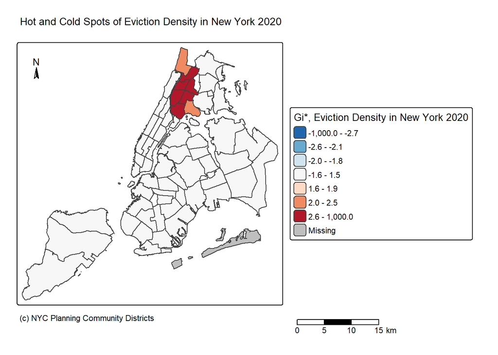

```r
#plot map
tm_shape(evictions_density) +
  tm_polygons(
    fill = "density_G",
    fill.scale = tm_scale_intervals(
      values = MoranColours,
      midpoint = NA,
      style = "fixed",
      breaks = breaks1
    ),
    fill.legend = tm_legend(
      title = "Gi*, Eviction Density in New York 2020",
      title.size = 0.85,
      size = 0.8,
      position = tm_pos_out("right",
                              "center",
                              pos.v = "center"))) +
  #Compass
  tm_compass(
    type = "arrow", size = 1,
             position = tm_pos_in("left", "top")) +
  #Scale Bar
  tm_scalebar(
    text.size = 0.7,
              position = tm_pos_out("right", "bottom")) +
  #Credits
  tm_credits(
    "(c) NYC Planning Community Districts",
             size = 0.7,
             position = tm_pos_out("center", "bottom")) +
  #Title
  tm_title("Hot and Cold Spots of Eviction Density in New York 2020")
```

The Gi* hotspot map identifies community districts with high value clustering (significantly high eviction density surrounded by similarly high-density neighbours) as hotspots, and districts with low value clustering (significantly low density surrounded by low-density neighbours) as cold spots.

## 4. Conclusion

In a policy perspective, these findings suggests that policy makers should prioritise efforts in focusing in districts with high eviction density, for effective eviction prevention and renter tenancy protection measures across geographically targetted districts.

## 5. Reflection and Limitations

- Limitation 1 (Data) : The analysis was limited to data for 2020 only, which may not be a full representation of eviction patterns across New York City.
- Limitation 2 (Method) : Other potential factors such as population that will influence eviction rates and patterns were not considered in this analysis due to data limitations, which future analysis could indicate.
- Limitation 3 (Temporal) : The year of 2020 was the period affected by the COVID-19 pandemic and eviction moratorium, therefore results may not be representative of eviction patterns across New York.

## 6. References

Nyc.gov. (2024). *Spotlight: New York City’s Rental Housing Market*. [online] Available at: https://comptroller.nyc.gov/reports/spotlight-new-york-citys-rental-housing-market/.

Hartman, C. and Robinson, D. (2003). Evictions: The hidden housing problem. *Housing Policy Debate*, 14(4), pp.461–501. doi:https://doi.org/10.1080/10511482.2003.9521483.

Hepburn, P., Louis, R., Fish, J., Lemmerman, E., Alexander, A.K., Thomas, T.A., Koehler, R., Benfer, E. and Desmond, M. (2021). U.S. Eviction Filing Patterns in 2020. *Socius: Sociological Research for a Dynamic World*, 7, p.237802312110099. doi:https://doi.org/10.1177/23780231211009983.

Homes and Community Renewal (2019). *Housing Stability & Tenant Protection Act.* [online] Available at: https://hcr.ny.gov/system/files/documents/2021/08/rent-laws-overview-english-10-2019.pdf

MacLachlan, A. (2025). *CASA0005 Geographic Information Systems and Science*. [online] Github.io. Available at: https://andrewmaclachlan.github.io/CASA0005repo/

Stack Overflow. (n.d.). *Changing date format in R*. [online] Available at: https://stackoverflow.com/questions/7439977/changing-date-format-in-r.

R-bloggers. (2022). *Replace NA with Zero in R | R-bloggers*. [online] Available at: https://www.r-bloggers.com/2022/06/replace-na-with-zero-in-r/

‌OpenAI (2025). *ChatGPT*. [online] chatgpt.com. Available at: https://chatgpt.com.